# Countywide Town Hall Report - Data Prep & Methods

LD

Load demographic and response rate data that was prepared long ago.

```r
knitr::opts_chunk$set(echo = TRUE, warning = FALSE, message = FALSE)

library(formattable)
library(dplyr)
library(data.table)
library(ggplot2)
library(flextable)
library(officer)
library(knitr)
library(ggthemes)
library(stringr)
library(docxtools)
library(tidyr)
library(tidycensus)
library(grid)
library(foreign)
library(extrafont)

# set path
wcl_root <- "W:/Project/RDA Team/Census2020/data/"

#### HARD CODED DATE ####
# load most recent standardized data for full county
dat <- fread(paste0(wcl_root, "convener_reports/standardized_data_test2020-10-05.csv"), data.table = FALSE, stringsAsFactors = FALSE,
             colClasses = c("GEOID"="character"))

dat <- fread(paste0(wcl_root, "convener_reports/standardized_data_test2020-10-05.csv"), data.table = FALSE, stringsAsFactors = FALSE,
             colClasses = c("GEOID"="character"))

# set up object for state rate
state_rate_cur <- subset(dat, level =="state"  & subject == "Response Rate" & value=="2020")$estimate
# object for current county rate
county_rate_cur <- unique(subset(dat, level =="county"  & subject == "Response Rate" & value=="2020")$estimate)


# load most recent response rate/tract compare data
change <- fread(paste0(wcl_root, "self_response/selfresp_tract_converted_change_2020-10-05.csv"), data.table = FALSE, stringsAsFactors = FALSE,
                colClasses = c("GEOID"="character"))

# calc uncounted hh--if household count is 0 make NA, otherwise subtracted est. # of hh that responded from total households
change$uncounted_hh =  ifelse(change$housecur ==0, NA, round(change$housecur - change$resp_house10,0))

change$region_name <- ifelse(change$region_name=="Northeast/Eastside/East LA", "Northeast-Eastside-East LA",
                                     change$region_name)

data_date <- unique(change$date.y)[1]

#### DATA THAT DOESN'T CHANGE ####
# load demographic data
demog <-  fread(paste0(wcl_root, "convener_reports/Demographic_Language_AllLevels.csv"), stringsAsFactors = FALSE, data.table = FALSE,
                colClasses = c("GEOID"="character"))

demog_county <- demog[demog$level=="county" & demog$GEOID=="06037" & demog$subject=="Race-Ethnicity",]

# query tracts only
demog <- demog[demog$level =="tract",]


# read in state dbf of htc data
htc <- read.dbf(paste0(wcl_root, "State Census Office/CA_HTC_2020Update.dbf"))
htc$GEOID_1 <- as.character(htc$GEOID_1)

# query only LA Co, keep only columns with tract id and HTC score & top 3 attributes contributing to HTC score
htc <- htc[htc$county_fip=="037", c(3, 17, 41:43)]
```

#### Data as of 2020-10-05

## Summarize HTC by neighborhood

Get mean HTC of tracts by neighborhood.

```r
# join response rate tracts and htc
neigh_meanhtc <-
change %>%
    left_join(htc, by=c("GEOID"="GEOID_1")) %>%
  group_by(neighbrhd_name, region_name) %>%
  summarize(mean_htc = mean(CAHTCI_202, na.rm=T)) %>%
  left_join(

change %>%
    left_join(htc, by=c("GEOID"="GEOID_1")) %>%
  group_by(neighbrhd_name, region_name) %>%
  filter(CAHTCI_202 >=57) %>%
  summarize(count_htc = length(CAHTCI_202)))

head(neigh_meanhtc)
```

```
## # A tibble: 6 x 4
## # Groups:   neighbrhd_name [6]
##   neighbrhd_name  region_name             mean_htc count_htc
##   <chr>           <chr>                      <dbl>     <int>
## 1 Acton           Antelope Valley             15.5        NA
## 2 Adams-Normandie South LA                    93           5
## 3 Addams          Long Beach                  73           2
## 4 Agoura Hills    West LA                     10.3        NA
## 5 Agua Dulce      Antelope Valley             12          NA
## 6 Alhambra        San Gabriel Valley West     52.9         8
```

I’m going to use the mean htc score and count of htc tracts per neighborhood to help rank priority communities in the next step.

## What are the prioirty communities?

### Rank communities by highest to lowest priority

1. Set up the data so that you are pulling response rates for neighborhoods/communities.
2. Join mean HTC score and HTC tract count per community.
3. Group by region name and rank each neighborhood response rate, mean HTC, HTC tract count, and uncounted housholds. The rank 1 indicates the highest priority community for that attribute.
4. Sum all rankings for a neighborhood. The neighborhood with the lowest summed rank is the highest priority.
5. Filter out racts with 200 or fewer households left to be counted.

```r
resprate <-
dat %>%
# filter data only to neighborhoods, only records for response rates and uncounted households
    filter(level =="Neighborhood" & value =="2020" & subject %in% c("Response Rate", "Uncounted Households")) %>%
   select(region_name, NAME, estimate,  subject) %>%

# make table wider so resp rate and uncounted hh are side-by-side columns
  pivot_wider(names_from = subject, values_from = estimate) %>%

# join neighborhood mean HTC scores
  left_join(neigh_meanhtc, by=c("NAME"="neighbrhd_name", "region_name"="region_name"))  %>%

# order the table by response rate and mean htc
  arrange(`Response Rate`, mean_htc) %>%

# group by region name
  group_by(region_name) %>%

# rank response rate, mean htc, count of htc tracts, and number of uncounted hhs. Higher priority = lower number.
# sum ranks, and the region with the lowest total rank is the highest priority
  mutate(
        # response rate--give less priority (divide by 2)
         rank_resp = rank(`Response Rate`, ties.method = "first")/2,

         # give htc more priority by making low scores lower (subtract by 1)
         rank_htc = rank(-mean_htc, ties.method = "first")-1,

         # penalize a neighborhood with 20 "points" if there are no htc tracts in the neighborhood
         rank_cnthtc = ifelse(!is.na(count_htc), rank(-count_htc, ties.method = "first"), 20),
         rank_uncthh = rank(-`Uncounted Households`, ties.method = "first"),

         # sum ranks
         rank_tot = rank_resp + rank_htc + rank_uncthh +rank_cnthtc) %>%

  # filter out neighborhoods with fewer than 200 hh left to count--not priority
   filter(`Uncounted Households` > 200)

# review
head(resprate)
```

```
## # A tibble: 6 x 11
## # Groups:   region_name [4]
##   region_name NAME  `Response Rate` `Uncounted Hous~ mean_htc count_htc
##   <chr>       <chr>           <dbl>            <dbl>    <dbl>     <int>
## 1 Santa Clar~ Nort~            35.2              371     30          NA
## 2 South LA    Univ~            39.2             3429     96.7         7
## 3 Central LA  Down~            41.2            16644     91.6        13
## 4 West LA     Mali~            41.6             3369     20          NA
## 5 South LA    Hist~            42.5             6421     98.8        12
## 6 West LA     Cent~            43.7              774     45          NA
## # ... with 5 more variables: rank_resp <dbl>, rank_htc <dbl>,
## #   rank_cnthtc <dbl>, rank_uncthh <int>, rank_tot <dbl>
```

```r
## addition 10/5/20 : remove the regional grouping so that we have priority neighborhoods county wide

resprate_Countywide <-
dat %>%
# filter data only to neighborhoods, only records for response rates and uncounted households
    filter(level =="Neighborhood" & value =="2020" & subject %in% c("Response Rate", "Uncounted Households")) %>%
   select(region_name, NAME, estimate,  subject) %>%

# make table wider so resp rate and uncounted hh are side-by-side columns
  pivot_wider(names_from = subject, values_from = estimate) %>%

# join neighborhood mean HTC scores
  left_join(neigh_meanhtc, by=c("NAME"="neighbrhd_name", "region_name"="region_name"))  %>%

# order the table by response rate and mean htc
  arrange(`Response Rate`, mean_htc) %>%

# rank response rate, mean htc, count of htc tracts, and number of uncounted hhs. Higher priority = lower number.
# sum ranks, and the region with the lowest total rank is the highest priority
  mutate(
        # response rate--give less priority (divide by 2)
         rank_resp = rank(`Response Rate`, ties.method = "first")/2,

         # give htc more priority by making low scores lower (subtract by 1)
         rank_htc = rank(-mean_htc, ties.method = "first")-1,

         # penalize a neighborhood with 20 "points" if there are no htc tracts in the neighborhood
         rank_cnthtc = ifelse(!is.na(count_htc), rank(-count_htc, ties.method = "first"), 20),
         rank_uncthh = rank(-`Uncounted Households`, ties.method = "first"),

         # sum ranks
         rank_tot = rank_resp + rank_htc + rank_uncthh +rank_cnthtc) %>%

  # filter out neighborhoods with fewer than 200 hh left to count--not priority
   filter(`Uncounted Households` > 200)

# review
head(resprate_Countywide)
```

```
## # A tibble: 6 x 11
##   region_name NAME  `Response Rate` `Uncounted Hous~ mean_htc count_htc
##   <chr>       <chr>           <dbl>            <dbl>    <dbl>     <int>
## 1 Santa Clar~ Nort~            35.2              371     30          NA
## 2 South LA    Univ~            39.2             3429     96.7         7
## 3 Central LA  Down~            41.2            16644     91.6        13
## 4 West LA     Mali~            41.6             3369     20          NA
## 5 South LA    Hist~            42.5             6421     98.8        12
## 6 West LA     Cent~            43.7              774     45          NA
## # ... with 5 more variables: rank_resp <dbl>, rank_htc <dbl>,
## #   rank_cnthtc <dbl>, rank_uncthh <int>, rank_tot <dbl>
```

### Select priority communities by region

Note that some regions have very few HTC tracts. This method allows for varying numbers of priority communities across regions, so that there aren’t an even top 5 communities picked per region. For example, Santa Clarita only has 3 HTC tracts in the city of Santa Clarita, so I don’t want to pick any of the other relatively well-off communities.

1. Query only regions with a mean HTC score above 50 or that have a HTC rank of 3 or less (in the cases of communities that are top-ranked in the region for HTC but the mean HTC score is relatively low).
2. Remove neighborhoods where there are 0-1 HTC tracts. I want a neighborhood to have at least 2 HTC tracts to get selected as a priority community.
3. Select the lowest 5 ranked records per region.
4. Create variable that codes regions into broader regions (this is how we do our WCLA presentations).
5. Export list of priority regions.

```r
# finalize priority neighborhoods by region
priority_neigh <-
resprate %>%

# screen out neighborhoods with an average HTC below 50 or who are not in the top 3 for HTC rates. Also screen out neighborhoods without HTC tracts.
  filter((mean_htc > 50 | rank_htc <= 3) & !is.na(count_htc) & count_htc > 1) %>%

  # select the 5 records with the lowest rank total score
  top_n(-5, wt=rank_tot)

head(priority_neigh)
```

```
## # A tibble: 6 x 11
## # Groups:   region_name [3]
##   region_name NAME  `Response Rate` `Uncounted Hous~ mean_htc count_htc
##   <chr>       <chr>           <dbl>            <dbl>    <dbl>     <int>
## 1 Central LA  Down~            41.2            16644     91.6        13
## 2 South LA    Hist~            42.5             6421     98.8        12
## 3 South LA    Cent~            46.2             5300     90.7        10
## 4 Central LA  Pico~            48.7             7087    103.         14
## 5 South LA    Watts            49.5             4915     89           8
## 6 West LA     West~            50               9310     54           5
## # ... with 5 more variables: rank_resp <dbl>, rank_htc <dbl>,
## #   rank_cnthtc <dbl>, rank_uncthh <int>, rank_tot <dbl>
```

```r
# finalize priority neighborhoods by countywide
priority_neigh_Countywide <-
resprate_Countywide %>%

# screen out neighborhoods with an average HTC below 50 or who are not in the top 3 for HTC rates. Also screen out neighborhoods without HTC tracts.
  filter((mean_htc > 50 | rank_htc <= 3) & !is.na(count_htc) & count_htc > 1) %>%

  # select the 25 records with the lowest rank total score (highest priority countywide)
  top_n(-25, wt=rank_tot)

head(priority_neigh_Countywide)
```

```
## # A tibble: 6 x 11
##   region_name NAME  `Response Rate` `Uncounted Hous~ mean_htc count_htc
##   <chr>       <chr>           <dbl>            <dbl>    <dbl>     <int>
## 1 South LA    Univ~            39.2             3429     96.7         7
## 2 Central LA  Down~            41.2            16644     91.6        13
## 3 South LA    Hist~            42.5             6421     98.8        12
## 4 South LA    Cent~            46.2             5300     90.7        10
## 5 Central LA  Pico~            48.7             7087    103.         14
## 6 South LA    Sout~            49.1             4662     87.9         8
## # ... with 5 more variables: rank_resp <dbl>, rank_htc <dbl>,
## #   rank_cnthtc <dbl>, rank_uncthh <int>, rank_tot <dbl>
```

```r
# code broader neighborhood groups
priority_neigh$reg_big <- ifelse(priority_neigh$region_name %in% c("Antelope Valley", "Santa Clarita"), "AV-Santa Clarita",
                          ifelse(priority_neigh$region_name %in% c("Central LA", "West LA", "Northeast-Eastside-East LA"), "Metro LA",
                          ifelse(priority_neigh$region_name %in% c("San Gabriel Valley East", "San Gabriel Valley West", "Pomona Valley"), "SGV-Pomona",
                          ifelse(priority_neigh$region_name %in% c("South Bay West", "South Bay East", "South LA"), "South LA-S Bay",
                                 priority_neigh$region_name))))


# code broader neighborhood groups
priority_neigh_Countywide$reg_big <- ifelse(priority_neigh_Countywide$region_name %in% c("Antelope Valley", "Santa Clarita"), "AV-Santa Clarita",
                          ifelse(priority_neigh_Countywide$region_name %in% c("Central LA", "West LA", "Northeast-Eastside-East LA"), "Metro LA",
                          ifelse(priority_neigh_Countywide$region_name %in% c("San Gabriel Valley East", "San Gabriel Valley West", "Pomona Valley"), "SGV-Pomona",
                          ifelse(priority_neigh_Countywide$region_name %in% c("South Bay West", "South Bay East", "South LA"), "South LA-S Bay",
                                 priority_neigh_Countywide$region_name))))


# export priority neighborhood data
write.csv(priority_neigh, paste0(wcl_root, "Countywide Town Hall Reports/priority_neighborhoods.csv"), row.names = FALSE)

# export priority neighborhood data
write.csv(priority_neigh, paste0(wcl_root, "Countywide Town Hall Reports/priority_neighborhoods_", data_date, ".csv"), row.names = FALSE)



# export priority neighborhood data COUNTYWIDE (added 10/5/20)
write.csv(priority_neigh_Countywide, paste0(wcl_root, "Countywide Town Hall Reports/priority_neighborhoodsCountywide_", data_date, ".csv"), row.names = FALSE)
```

### Summary stats on priority neighborhoods

Select tracts that are in the priority neighborhoods and calculate summary stats.

```r
###### priority neighborhoods change based on response rate data

# list of priority neighborhood names
priority_neigh_names <- priority_neigh$NAME

###### Demographic data does not change

# join tract demographic and response rate data and filter by priority neighborhoods
pri_demog <-
demog %>%
  select(GEOID, value, subject, estimate, summary_est, prc, prc_cv) %>%
  left_join(change, by="GEOID") %>%

  # select only tracts in neighborhoods in the priority neighborhood list
  filter(neighbrhd_name %in% priority_neigh_names & subject !="Household Count") %>%

  # Group by region name and neighborhood and get demographics
  group_by(region_name, neighbrhd_name, subject, value) %>%

  summarize(est = sum(estimate, na.rm=T),
            tot = sum(summary_est, na.rm=T),
            prc = est/tot) %>%

  # join big umbrella region name
  left_join(priority_neigh %>% select(region_name, NAME, reg_big), by=c("region_name"="region_name", "neighbrhd_name"="NAME"))


head(pri_demog)
```

```
## # A tibble: 6 x 8
## # Groups:   region_name, neighbrhd_name, subject [2]
##   region_name  neighbrhd_name subject   value    est    tot     prc reg_big
##   <chr>        <chr>          <chr>     <chr>  <int>  <int>   <dbl> <chr>
## 1 Antelope Va~ Lancaster      Foreign ~ forei~ 16529 155605 1.06e-1 AV-San~
## 2 Antelope Va~ Lancaster      Language~ Arabic   200 143271 1.40e-3 AV-San~
## 3 Antelope Va~ Lancaster      Language~ Chine~   231 143271 1.61e-3 AV-San~
## 4 Antelope Va~ Lancaster      Language~ Frenc~   130 143271 9.07e-4 AV-San~
## 5 Antelope Va~ Lancaster      Language~ Germa~    24 143271 1.68e-4 AV-San~
## 6 Antelope Va~ Lancaster      Language~ Korean   380 143271 2.65e-3 AV-San~
```

#### Test plot race/ethnicity by priority community

Test for Metro LA (West LA, Central LA and NELA)

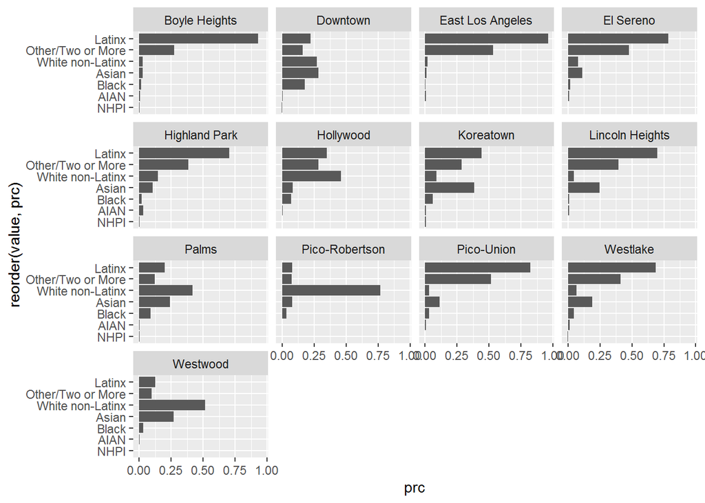

```r
# try plotting demographics by priority community
ggplot(subset(pri_demog, subject=="Race-Ethnicity" & value !="Total" & reg_big=="Metro LA"),
       aes(y = prc, x= reorder(value, prc))) +
  geom_bar(position = "stack", stat = "identity")+
  facet_wrap(~neighbrhd_name) +
  coord_flip()
```